# zadanie4_bagin.R

samuelbagin

2026-10-28

# zadanie 4

Samuel Bagin

```r
library(readxl)
library(ggplot2)
library(viridisLite)
library(car)
library(latex2exp)

alfa <- 0.05
alfa_dva <- 0.10
farby <- viridis(5, end = 0.8)
```

# 1. import a kontrola dat

```r
cesty_skriptov <- c(
  sub("^--file=", "", grep("^--file=", commandArgs(), value = TRUE)),
  unlist(lapply(sys.frames(), function(ramec) ramec$ofile), use.names = FALSE)
)
priecinok <- if (length(cesty_skriptov) > 0) {
  dirname(normalizePath(tail(cesty_skriptov, 1)))
} else {
  getwd()
}

prijem <- as.data.frame(read_xlsx(file.path(priecinok, "prijem.xlsx"), sheet = 1))
dieta <- as.data.frame(read_xlsx(file.path(priecinok, "dieta.xlsx"), sheet = 1))
names(prijem) <- tolower(names(prijem))
names(dieta) <- tolower(names(dieta))
str(prijem)
```

```
## 'data.frame':    235 obs. of  6 variables:
##  $ respondent: num  1 2 3 4 5 6 7 8 9 10 ...
##  $ vek       : num  1 3 5 5 1 1 2 3 4 2 ...
##  $ vzdelanie : num  2 1 1 3 1 2 4 2 3 1 ...
##  $ miesto    : num  2 1 4 2 2 3 3 4 3 3 ...
##  $ sektor    : num  3 2 2 3 2 3 1 2 2 1 ...
##  $ prijem    : num  13889 12532 13922 12896 13261 ...
```

```r
head(prijem)
```

```
##   respondent vek vzdelanie miesto sektor   prijem
## 1          1   1         2      2      3 13888.64
## 2          2   3         1      1      2 12531.66
## 3          3   5         1      4      2 13922.18
## 4          4   5         3      2      3 12896.36
## 5          5   1         1      2      2 13260.99
## 6          6   1         2      3      3 14888.62
```

```r
colSums(is.na(prijem))
```

```
## respondent        vek  vzdelanie     miesto     sektor     prijem
##          0          0          0          0          0          0
```

```r
sum(duplicated(prijem))
```

```
## [1] 0
```

```r
anyDuplicated(prijem$respondent)
```

```
## [1] 0
```

```r
str(dieta)
```

```
## 'data.frame':    202 obs. of  3 variables:
##  $ pohlavie: chr  "F" "F" "F" "F" ...
##  $ pred    : num  88.7 93 95.2 95.5 96.1 ...
##  $ po      : num  95.2 92.6 98.8 93.1 94.7 ...
```

```r
head(dieta)
```

```
##   pohlavie  pred    po
## 1        F 88.66 95.22
## 2        F 92.95 92.57
## 3        F 95.25 98.79
## 4        F 95.48 93.11
## 5        F 96.11 94.72
## 6        F 96.16 93.58
```

```r
colSums(is.na(dieta))
```

```
## pohlavie     pred       po
##        0        0        0
```

```r
sum(duplicated(dieta))
```

```
## [1] 0
```

```r
stopifnot(nrow(prijem) == 235, nrow(dieta) == 202,
          !anyNA(prijem), !anyNA(dieta), anyDuplicated(prijem$respondent) == 0,
          all(prijem$vek %in% 1:5), all(prijem$vzdelanie %in% 1:5),
          all(prijem$miesto %in% 1:4), all(prijem$sektor %in% 1:3),
          all(dieta$pohlavie %in% c("F", "M")),
          all(dieta$pred > 0), all(dieta$po > 0))

for (premenna in c("vek", "vzdelanie", "miesto", "sektor")) {
  prijem[[premenna]] <- factor(prijem[[premenna]])
}
dieta$pohlavie <- factor(dieta$pohlavie, levels = c("F", "M"), labels = c("zeny", "muzi"))
if (interactive()) {
  View(prijem)
  View(dieta)
}
```

prvy harok prijem obsahuje 235 osob dieta obsahuje 202 klientov. v analyzovanych tabulkach nie su chybajuce hodnoty ani zhodne riadky. prijem je cisty rocny prijem bez zadanej meny. pre jednofaktorove analyzy a dietu volime $\alpha = 0,05$, pre dvojfaktorove analyzy zadanie urcuje $\alpha = 0,10$.

## pomocne vypocty a grafy

```r
popis_skupin <- function(hodnoty, skupina, hladina = alfa) {
  vysledok <- do.call(rbind, lapply(split(hodnoty, skupina, drop = TRUE), function(x) {
    n <- length(x)
    chyba <- if (n > 1) qt(1 - hladina / 2, n - 1) * sd(x) / sqrt(n) else NA_real_
    data.frame(n = n, priemer = mean(x), median = median(x), sd = sd(x), rozptyl = var(x),
               minimum = min(x), maximum = max(x), dolna = mean(x) - chyba, horna = mean(x) + chyba,
               p_shapiro = if (n >= 3) shapiro.test(x)$p.value else NA_real_)
  }))
  vysledok$skupina <- factor(rownames(vysledok), levels = levels(droplevels(skupina)))
  vysledok
}

graf_skupin <- function(data, hodnota, skupina, nazov, os_y) {
  ggplot(data, aes(x = .data[[skupina]], y = .data[[hodnota]], fill = .data[[skupina]])) +
    geom_boxplot(alpha = 0.6, outlier.shape = NA) +
    geom_point(aes(color = .data[[skupina]]),
               position = position_jitter(width = 0.10, height = 0, seed = 2026),
               alpha = 0.45, size = 1.3) +
    scale_fill_manual(values = farby, guide = "none") +
    scale_color_manual(values = farby, guide = "none") + theme_minimal() +
    labs(title = nazov, x = skupina, y = os_y)
}

graf_normality <- function(data, hodnota, skupina, nazov) {
  ggplot(data, aes(sample = .data[[hodnota]], color = .data[[skupina]])) +
    stat_qq(size = 1.3) + stat_qq_line() + facet_wrap(vars(.data[[skupina]])) +
    scale_color_manual(values = farby, guide = "none") + theme_minimal() +
    labs(title = nazov, x = "teoreticke kvantily", y = "vyberove kvantily")
}
```

# 2. prijem - jednofaktorova analyza rozptylu

pre kazdy faktor testujeme $H_0: \mu_1 = \cdots = \mu_k$, $H_1$: aspon dve stredne hodnoty sa lisia. normalita v skupinach: $H_0$: normalne rozdelenie, $H_1$: rozdelenie nie je normalne. Bartlettov test: $H_0: \sigma_1^2 = \cdots = \sigma_k^2$, $H_1$: aspon dva rozptyly sa lisia. pri splnenych predpokladoch pouzijeme ANOVA a po vyznamnom vysledku Tukeyho-Kramerov post hoc test. nezamietnutie $H_0$ nie je dokaz rovnosti priemerov ani dokaz splnenia predpokladov. mierou efektu je $\eta^2 = \frac{SS_{faktor}}{SS_{celkove}}$, teda podiel vysvetlenej variability prijmu.

```r
jednofaktorova <- function(premenna) {
  formula <- reformulate(premenna, response = "prijem")
  popis <- popis_skupin(prijem$prijem, prijem[[premenna]])
  print(popis)
  print(graf_skupin(prijem, "prijem", premenna, paste("rocny prijem podla", premenna), "cisty rocny prijem"))
  print(graf_normality(prijem, "prijem", premenna, paste("Q-Q grafy prijmu podla", premenna)))
  print(ggplot(popis, aes(skupina, priemer, ymin = dolna, ymax = horna, color = skupina)) +
          geom_pointrange() + scale_color_manual(values = farby, guide = "none") + theme_minimal() +
          labs(title = paste("priemery a 95 % intervaly -", premenna), x = premenna, y = "cisty rocny prijem"))

  bartlett <- bartlett.test(formula, data = prijem)
  print(bartlett)
  model <- aov(formula, data = prijem)
  tabulka <- summary(model)[[1]]
  print(summary(model))
  eta2 <- tabulka[1, "Sum Sq"] / sum(tabulka[, "Sum Sq"])
  print(c(eta2 = eta2))
  post <- NULL
  if (tabulka[1, "Pr(>F)"] < alfa) {
    post <- TukeyHSD(model, conf.level = 1 - alfa)
    print(post)
    plot(post, las = 1, col = farby[2])
  }

  # ANOVA sa podla zadania vypocita aj pri poruseni predpokladov.
  # Pri nerovnakych rozptyloch je alternativou Welchova ANOVA a Gamesov-Howellov post hoc test.
  # Pri silnej nenormalite zvazit robustnu analyzu priemerov alebo po odovodneni poradove testy.
  # Kruskalov-Wallisov test testuje poradia/rozdelenia, nie je vseobecne testom rovnosti priemerov.
  if (bartlett$p.value < alfa || any(popis$p_shapiro < alfa, na.rm = TRUE)) {
    print(oneway.test(formula, data = prijem, var.equal = FALSE))
    print(kruskal.test(formula, data = prijem))
  }
  list(popis = popis, bartlett = bartlett, model = model, tabulka = tabulka, eta2 = eta2, post = post)
}
```

## vek

```r
vek <- jednofaktorova("vek")
```

```
##    n  priemer   median       sd rozptyl   minimum  maximum    dolna    horna
## 1 51 13798.58 13887.26 1596.234 2547962 10024.071 17799.96 13349.63 14247.52
## 2 98 14147.28 14158.52 1817.635 3303796  9310.645 18581.67 13782.87 14511.69
## 3 20 14475.46 14578.48 1975.242 3901583 11101.604 17312.62 13551.02 15399.90
## 4 51 14300.88 14456.58 2184.696 4772895  9652.543 19380.43 13686.42 14915.33
## 5 15 12967.39 12991.87 1947.921 3794396  9278.995 15848.73 11888.67 14046.12
##   p_shapiro skupina
## 1 0.9491000       1
## 2 0.8371968       2
## 3 0.1745453       3
## 4 0.9257746       4
## 5 0.2824334       5
```

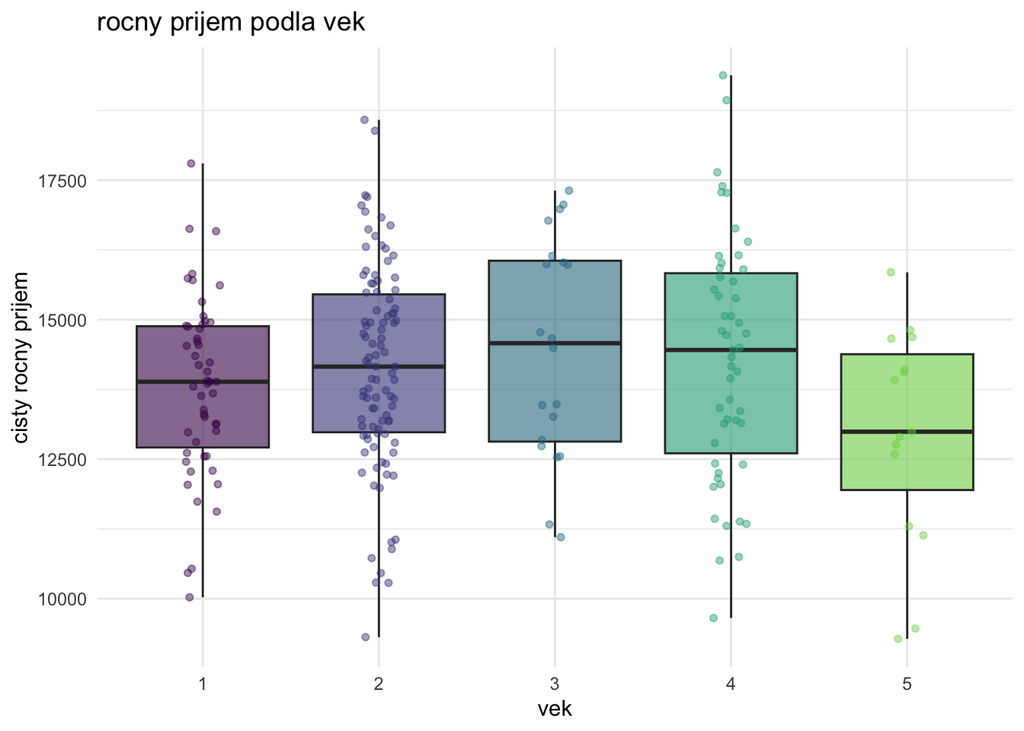

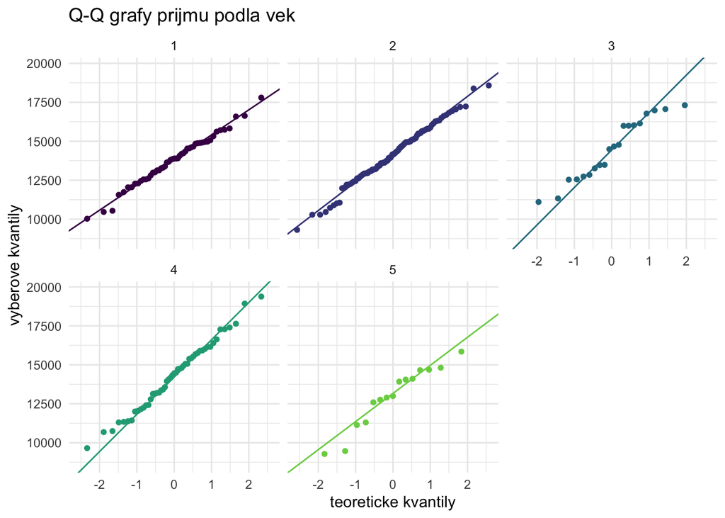

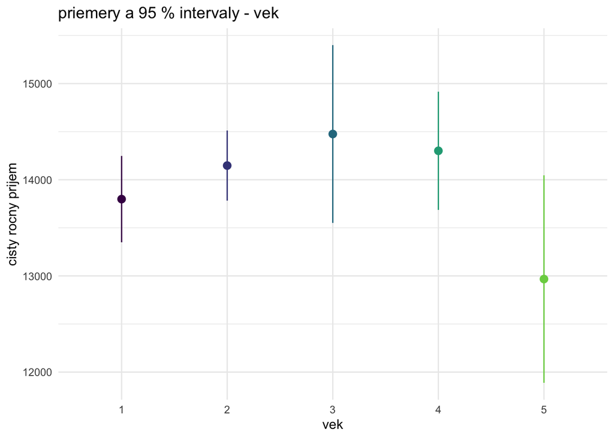

```
##
##  Bartlett test of homogeneity of variances
##
## data:  prijem by vek
## Bartlett's K-squared = 5.1822, df = 4, p-value = 0.2691
##
##              Df    Sum Sq Mean Sq F value Pr(>F)
## vek           4  28548693 7137173   2.017 0.0929 .
## Residuals   230 813762671 3538099
## ---
## Signif. codes:  0 '***' 0.001 '**' 0.01 '*' 0.05 '.' 0.1 ' ' 1
##       eta2
## 0.03389328
```

Shapirove testy ani Bartlettov test pri $\alpha = 0,05$ nezamietaju normalitu a rovnost rozptylov. ANOVA ($p = 0,09287$) nezamieta $H_0$, rozdiel priemerneho prijmu podla veku sa nepreukazal. Vek vysvetluje asi 3,39 % variability prijmu, post hoc test nie je potrebny.

## sektor

```r
sektor <- jednofaktorova("sektor")
```

```
##    n  priemer   median       sd rozptyl  minimum  maximum    dolna    horna
## 1 83 13983.38 13907.02 1898.237 3603304 9278.995 18931.50 13568.89 14397.88
## 2 75 14151.77 13923.87 2025.637 4103205 9310.645 19380.43 13685.71 14617.82
## 3 77 14045.74 14201.76 1784.695 3185135 9463.586 17272.87 13640.67 14450.82
##   p_shapiro skupina
## 1 0.9842727       1
## 2 0.8882605       2
## 3 0.1162947       3
```

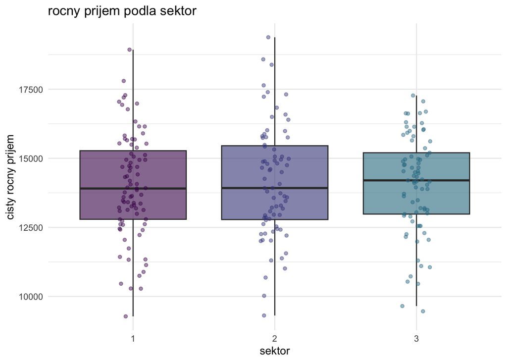

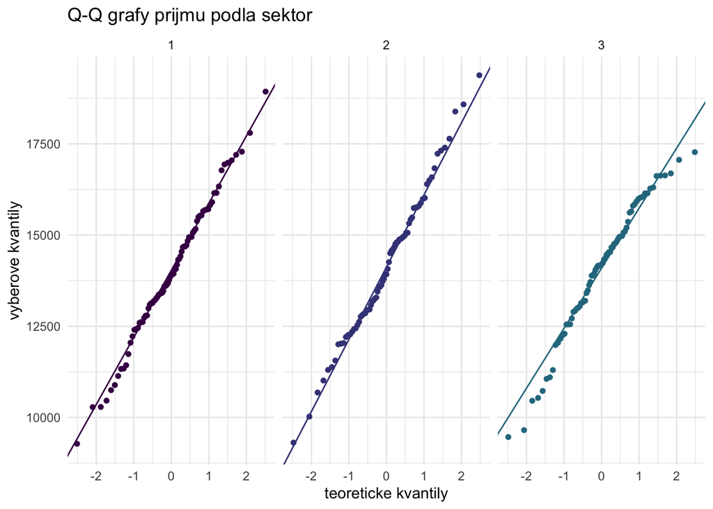

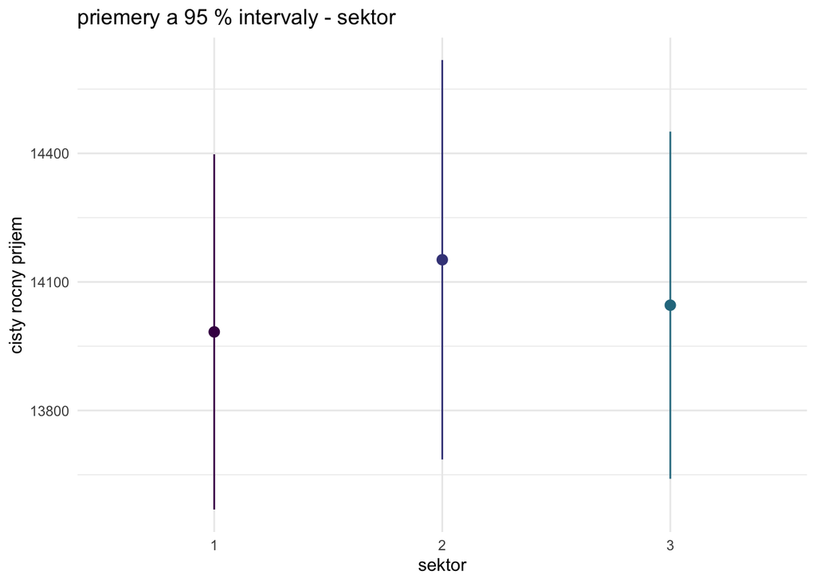

```
##
##  Bartlett test of homogeneity of variances
##
## data:  prijem by sektor
## Bartlett's K-squared = 1.1962, df = 2, p-value = 0.5498
##
##              Df    Sum Sq Mean Sq F value Pr(>F)
## sektor        2   1133014  566507   0.156  0.855
## Residuals   232 841178349 3625769
##        eta2
## 0.001345125
```

Shapirove testy ani Bartlettov test pri $\alpha = 0,05$ nezamietaju normalitu a rovnost rozptylov. ANOVA ($p = 0,85544$) nezamieta $H_0$, rozdiel priemerneho prijmu medzi sektormi sa nepreukazal. Sektor vysvetluje iba asi 0,13 % variability prijmu.

## vzdelanie

```r
vzdelanie <- jednofaktorova("vzdelanie")
```

```
##    n  priemer   median       sd rozptyl   minimum  maximum    dolna    horna
## 1 30 12989.51 13336.50 1851.317 3427374  9278.995 16332.68 12298.22 13680.80
## 2 58 13752.04 13737.02 1831.084 3352869  9652.543 17312.62 13270.58 14233.50
## 3 81 14347.57 14500.98 2071.064 4289306  9310.645 19380.43 13889.62 14805.52
## 4 44 14541.87 14410.24 1568.764 2461022 12040.048 17229.29 14064.93 15018.82
## 5 22 14283.01 14428.73 1463.014 2140409 10888.391 16617.86 13634.35 14931.67
##    p_shapiro skupina
## 1 0.59650955       1
## 2 0.62404448       2
## 3 0.55263352       3
## 4 0.06206539       4
## 5 0.66695270       5
```

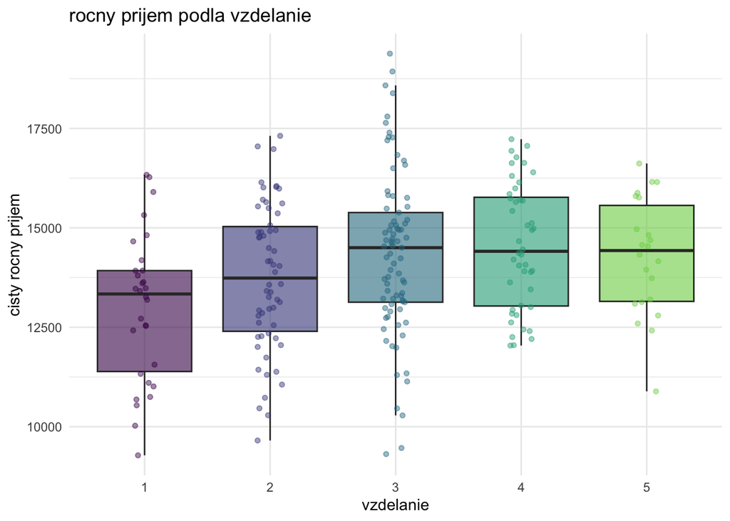

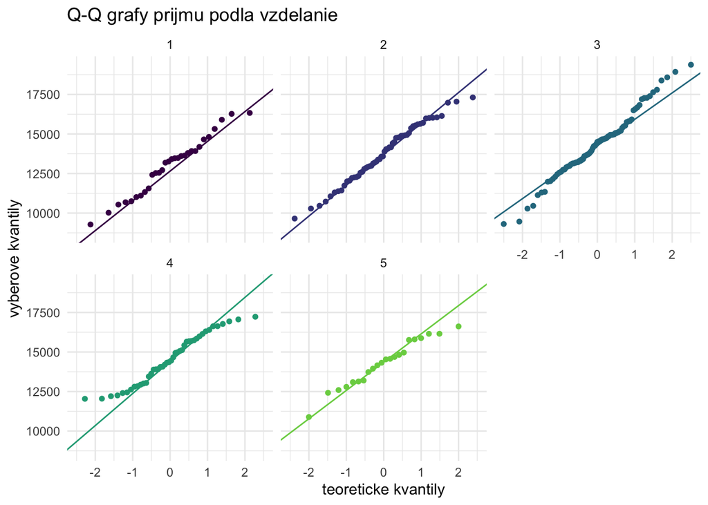

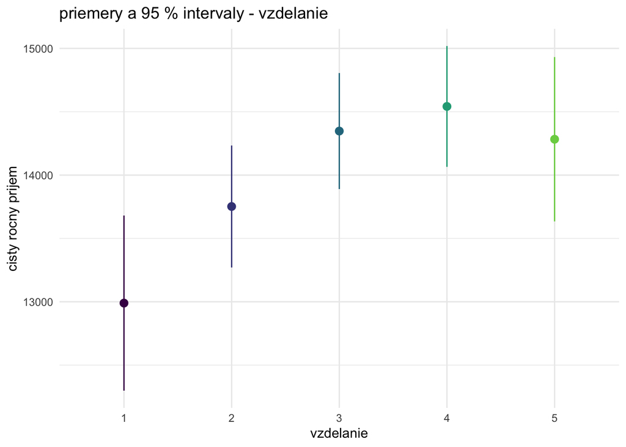

```
##
##  Bartlett test of homogeneity of variances
##
## data:  prijem by vzdelanie
## Bartlett's K-squared = 6.2349, df = 4, p-value = 0.1823
##
##              Df    Sum Sq  Mean Sq F value  Pr(>F)
## vzdelanie     4  57886978 14471744   4.243 0.00247 **
## Residuals   230 784424386  3410541
## ---
## Signif. codes:  0 '***' 0.001 '**' 0.01 '*' 0.05 '.' 0.1 ' ' 1
##       eta2
## 0.06872397
##   Tukey multiple comparisons of means
##     95% family-wise confidence level
##
## Fit: aov(formula = formula, data = prijem)
##
## $vzdelanie
##           diff        lwr      upr     p adj
## 2-1  762.53179  -379.3955 1904.459 0.3554415
## 3-1 1358.05738   272.8066 2443.308 0.0061450
## 4-1 1552.36316   350.0970 2754.629 0.0042228
## 5-1 1293.49913  -131.7850 2718.783 0.0952313
## 3-2  595.52558  -277.8934 1468.945 0.3339258
## 4-2  789.83137  -225.3216 1804.984 0.2071535
## 5-2  530.96734  -740.4596 1802.394 0.7805725
## 4-3  194.30579  -756.6447 1145.256 0.9803651
## 5-3  -64.55824 -1285.3357 1156.219 0.9998989
## 5-4 -258.86403 -1584.7495 1067.021 0.9834230
```

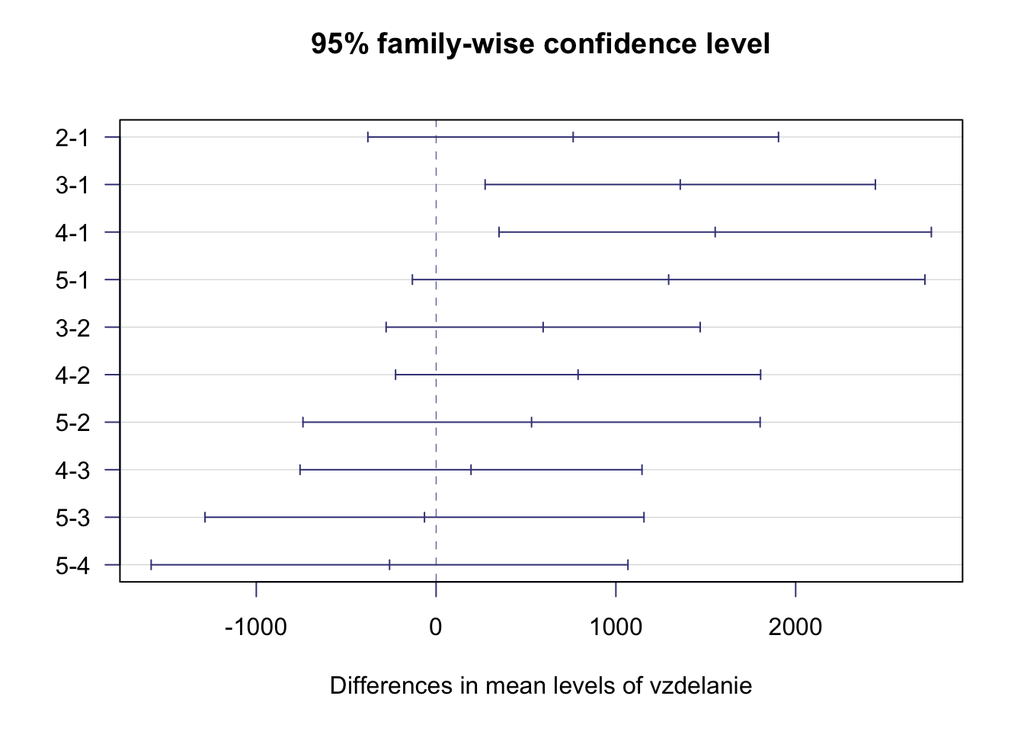

Normalitu ani rovnost rozptylov pri $\alpha = 0,05$ nezamietame. ANOVA ($p = 0,00247$) zamieta $H_0$, vzdelanie vysvetluje asi 6,87 % variability prijmu. Tukeyho test preukazal vyssi prijem skupin 3 a 4 oproti skupine 1, ostatne rozdiely nie su vyznamne.

## miesto vykonavania prace

```r
miesto <- jednofaktorova("miesto")
```

```
##    n  priemer   median       sd rozptyl   minimum  maximum    dolna    horna
## 1 36 12893.61 12871.32 2111.270 4457460  9278.995 17200.33 12179.26 13607.96
## 2 59 13343.12 13361.33 1526.349 2329740  9310.645 16980.85 12945.35 13740.88
## 3 74 14404.64 14661.25 1833.073 3360156  9463.586 19380.43 13979.95 14829.33
## 4 66 14941.95 14752.09 1600.291 2560930 12024.155 18581.67 14548.55 15335.35
##   p_shapiro skupina
## 1 0.2976549       1
## 2 0.5726176       2
## 3 0.4564413       3
## 4 0.2532084       4
```

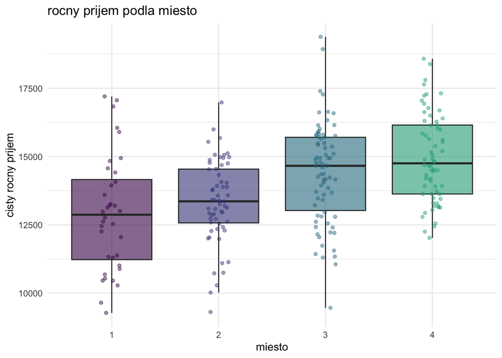

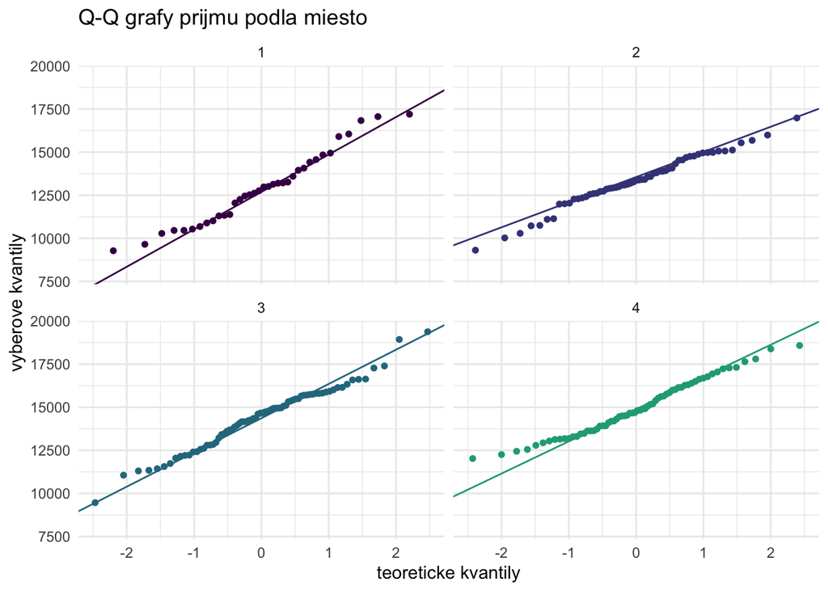

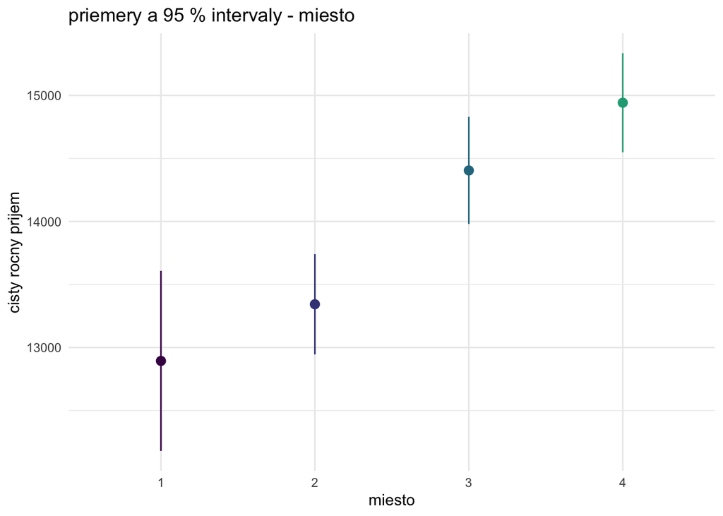

```
##
##  Bartlett test of homogeneity of variances
##
## data:  prijem by miesto
## Bartlett's K-squared = 6.0414, df = 3, p-value = 0.1096
##
##              Df    Sum Sq  Mean Sq F value   Pr(>F)
## miesto        3 139423434 46474478   15.27 4.24e-09 ***
## Residuals   231 702887929  3042805
## ---
## Signif. codes:  0 '***' 0.001 '**' 0.01 '*' 0.05 '.' 0.1 ' ' 1
##      eta2
## 0.1655248
##   Tukey multiple comparisons of means
##     95% family-wise confidence level
##
## Fit: aov(formula = formula, data = prijem)
##
## $miesto
##          diff       lwr      upr     p adj
## 2-1  449.5089 -505.1699 1404.188 0.6157514
## 3-1 1511.0342  593.7542 2428.314 0.0001717
## 4-1 2048.3402 1113.0431 2983.637 0.0000003
## 3-2 1061.5253  273.6515 1849.399 0.0032607
## 4-2 1598.8313  790.0525 2407.610 0.0000039
## 4-3  537.3060 -226.9677 1301.580 0.2668600
```

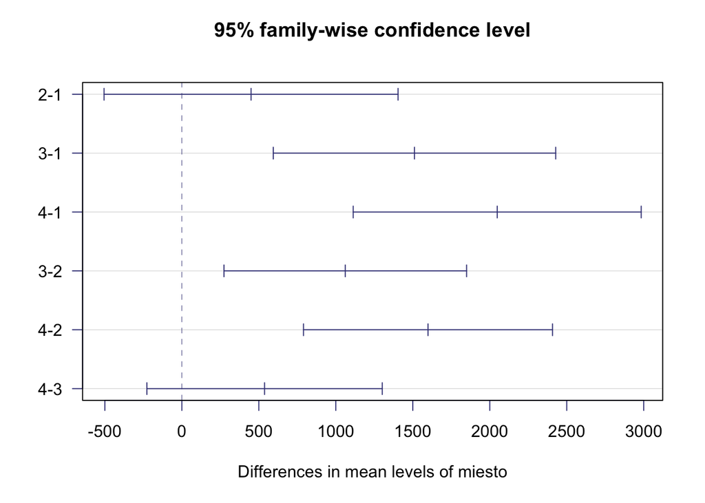

Normalitu ani rovnost rozptylov pri $\alpha = 0,05$ nezamietame. ANOVA ($p = 4,24 \times 10^{-9}$) zamieta $H_0$, miesto vysvetluje asi 16,55 % variability prijmu, najviac zo sledovanych faktorov. Tukeyho test preukazal vyssi prijem v okresnych a krajskych mestach oproti mensim obciam a mestam, ostatne rozdiely nie su vyznamne.

# 3. prijem - dvojfaktorova analyza rozptylu, $\alpha = 0,10$

## upravene priemery a post hoc testy

Upravene priemery pocitame z modelovych predikcii cez rovnako vazene urovne druheho faktora. Rozdiely overujeme t-testami linearnych kontrastov s Holmovou korekciou v ramci faktora jedneho modelu. 90 % intervaly rozdielov su neupravene, preto rozhodujeme podla $p_{Holm}$.

```r
upravene_porovnania <- function(model, data, premenna, druha, hladina = alfa_dva) {
  premenne <- c(premenna, druha)
  mriezka <- expand.grid(lapply(data[premenne], levels), stringsAsFactors = FALSE)
  names(mriezka) <- premenne
  for (v in premenne) mriezka[[v]] <- factor(mriezka[[v]], levels = levels(data[[v]]))
  X <- model.matrix(delete.response(terms(model)), data = mriezka, contrasts.arg = model$contrasts)
  L <- t(vapply(levels(data[[premenna]]), function(uroven) {
    colMeans(X[mriezka[[premenna]] == uroven, , drop = FALSE])
  }, numeric(ncol(X))))
  rownames(L) <- levels(data[[premenna]])
  odhady <- drop(L %*% coef(model))
  chyby <- sqrt(diag(L %*% vcov(model) %*% t(L)))
  kriticka <- qt(1 - hladina / 2, df.residual(model))
  priemery <- data.frame(skupina = factor(rownames(L), levels = levels(data[[premenna]])),
                         priemer = odhady, dolna = odhady - kriticka * chyby, horna = odhady + kriticka * chyby)

  dvojice <- combn(nrow(L), 2)
  testy <- do.call(rbind, lapply(seq_len(ncol(dvojice)), function(i) {
    a <- dvojice[1, i]
    b <- dvojice[2, i]
    kontrast <- L[b, ] - L[a, ]
    rozdiel <- sum(kontrast * coef(model))
    se <- sqrt(drop(kontrast %*% vcov(model) %*% kontrast))
    t <- rozdiel / se
    data.frame(dvojica = paste(rownames(L)[b], rownames(L)[a], sep = "-"),
               rozdiel = rozdiel, se = se, t = t, df = df.residual(model),
               dolna = rozdiel - kriticka * se, horna = rozdiel + kriticka * se,
               p = 2 * pt(abs(t), df.residual(model), lower.tail = FALSE))
  }))
  testy$p_holm <- p.adjust(testy$p, method = "holm")
  testy$vyznamny <- testy$p_holm < hladina
  list(priemery = priemery, testy = testy)
}

dvojfaktorova <- function(prvy, druhy) {
  premenne <- c(prvy, druhy)
  cat("\n", paste(premenne, collapse = " + "), "\n")
  pocty <- table(prijem[premenne])
  print(pocty)
  bunky <- interaction(prijem[premenne], drop = TRUE)
  popis <- popis_skupin(prijem$prijem, bunky, hladina = alfa_dva)
  print(popis)
  cat("prazdne bunky:", sum(pocty == 0), ", obsadene bunky s menej ako 3 osobami:",
      sum(pocty > 0 & pocty < 3), "\n")
  # Shapiro sa da vypocitat od troch osob. NA neoznacuje splnenu normalitu.
  # Pri mnohych testoch normality moze jednotliva mala p-hodnota vzniknut aj nahodou.
  levene <- car::leveneTest(prijem$prijem, bunky, center = median)
  print(levene)

  aditivny <- lm(reformulate(premenne, response = "prijem"), data = prijem)
  plny <- lm(as.formula(paste("prijem ~", prvy, "*", druhy)), data = prijem)
  interakcia <- anova(aditivny, plny)
  print(interakcia)
  p_interakcia <- interakcia[2, "Pr(>F)"]
  cat("parcialne eta2 interakcie:", (deviance(aditivny) - deviance(plny)) / deviance(aditivny), "\n")
  print(shapiro.test(residuals(plny)))

  # Pre dodane data sa vsade vyberie aditivny model. Ak by interakcia bola vyznamna,
  # interpretovali by sme jednoduche efekty A v jednotlivych urovniach B a naopak.
  if (p_interakcia < alfa_dva) {
    stop("Vyznamna interakcia: treba porovnat jednoduche efekty namiesto aditivnych priemerov.")
  }
  print(anova(lm(prijem ~ 1, data = prijem), aditivny))
  hlavne <- drop1(aditivny, test = "F")
  print(hlavne)
  efekty <- data.frame(faktor = premenne,
                       parcialne_eta2 = hlavne[premenne, "Sum of Sq"] /
                         (hlavne[premenne, "Sum of Sq"] + deviance(aditivny)))
  print(efekty)
  print(c(R2 = summary(aditivny)$r.squared))
  print(shapiro.test(residuals(aditivny)))

  # Doplnkova kontrola citlivosti: HC3 upravuje kovariancnu maticu pri nerovnakych rozptyloch.
  # Nie je to oprava prazdnych buniek ani zaruka spravnosti pri velmi malych skupinach.
  robustne <- car::Anova(aditivny, type = 2, white.adjust = "hc3")
  print(robustne)

  graf_data <- prijem
  graf_data$reziduum <- residuals(aditivny)
  graf_data$odhad <- fitted(aditivny)
  print(ggplot(graf_data, aes(odhad, reziduum)) +
          geom_point(color = farby[2], alpha = 0.55) + geom_hline(yintercept = 0, linetype = 2) +
          theme_minimal() + labs(title = paste("rezidua -", prvy, "+", druhy),
                                 x = "odhadnuty prijem", y = "reziduum"))
  print(ggplot(graf_data, aes(sample = reziduum)) + stat_qq(color = farby[2]) + stat_qq_line() +
          theme_minimal() + labs(title = paste("Q-Q graf rezidui -", prvy, "+", druhy),
                                 x = "teoreticke kvantily", y = "vyberove kvantily"))
  print(ggplot(prijem, aes(x = .data[[prvy]], y = prijem, color = .data[[druhy]], group = .data[[druhy]])) +
          stat_summary(fun = mean, geom = "line", linewidth = 0.6) +
          stat_summary(fun = mean, geom = "point", size = 2) +
          scale_color_manual(values = farby) + theme_minimal() +
          labs(title = paste("interakcny graf -", prvy, "a", druhy),
               subtitle = "pozorovane priemery obsadenych buniek", x = prvy, y = "priemerny rocny prijem", color = druhy))
  print(ggplot(prijem, aes(x = .data[[prvy]], y = prijem, fill = .data[[prvy]])) +
          geom_boxplot(alpha = 0.65) + facet_wrap(vars(.data[[druhy]])) +
          scale_fill_manual(values = farby, guide = "none") + theme_minimal() +
          labs(title = paste("rozdelenie prijmu -", prvy, "podla", druhy), x = prvy, y = "cisty rocny prijem"))

  post <- list()
  for (v in premenne) {
    if (hlavne[v, "Pr(>F)"] < alfa_dva) {
      dalsia <- setdiff(premenne, v)
      post[[v]] <- upravene_porovnania(aditivny, prijem, v, dalsia)
      cat("\nupravene priemery a post hoc testy:", v, "\n")
      print(post[[v]]$priemery)
      print(post[[v]]$testy)
      print(ggplot(post[[v]]$priemery, aes(skupina, priemer, ymin = dolna, ymax = horna, color = skupina)) +
              geom_pointrange() + scale_color_manual(values = farby, guide = "none") + theme_minimal() +
              labs(title = paste("upravene priemery -", v, "pri zohladneni", dalsia),
                   subtitle = "bodove 90 % intervaly spolahlivosti", x = v, y = "upraveny rocny prijem"))
    }
  }
  list(pocty = pocty, popis = popis, levene = levene, plny = plny, model = aditivny,
       interakcia = interakcia, hlavne = hlavne, efekty = efekty, robustne = robustne, post = post)
}
```

## miesto a vzdelanie

```r
miesto_vzdelanie <- dvojfaktorova("miesto", "vzdelanie")
```

```
##
##  miesto + vzdelanie
##       vzdelanie
## miesto  1  2  3  4  5
##      1  7  8 11  5  5
##      2  9 19 19  8  4
##      3  7 19 29 12  7
##      4  7 12 22 19  6
##      n  priemer   median        sd   rozptyl   minimum  maximum    dolna
## 1.1  7 11610.75 11012.48 2127.2706 4525280.2  9278.995 15902.16 10048.37
## 2.1  9 12392.99 12716.62 1424.3999 2028915.1 10024.071 13923.87 11510.08
## 3.1  7 13909.51 13605.56 1655.6660 2741229.9 11559.758 16332.68 12693.50
## 4.1  7 14215.24 13922.18 1049.7963 1102072.3 13188.751 16274.47 13444.21
## 1.2  8 12441.54 12153.98 2091.4536 4374178.1  9652.543 16052.05 11040.61
## 2.2 19 13293.14 13194.89 1530.7596 2343225.1 10287.497 16980.85 12684.17
## 3.2 19 13851.32 14166.27 1705.0516 2907201.1 11058.067 16143.55 13173.01
## 4.2 12 15195.13 15338.63 1448.1586 2097163.4 12551.216 17312.62 14444.36
## 1.3 11 13265.37 12981.61 2289.7333 5242878.5 10283.204 17200.33 12014.08
## 2.3 19 13328.92 13361.33 1509.1757 2277611.4  9310.645 15065.53 12728.53
## 3.3 29 14798.83 14722.81 2060.7155 4246548.2  9463.586 19380.43 14147.87
## 4.3 22 15173.57 14927.20 1918.6010 3681029.9 12024.155 18581.67 14469.70
## 1.4  5 14340.96 14070.93 1772.7805 3142750.7 12620.758 17060.94 12650.81
## 2.4  8 14636.76 15022.68 1245.9398 1552365.9 12040.048 15992.61 13802.18
## 3.4 12 14155.98 14208.47 1645.9688 2709213.4 12048.684 16634.17 13302.66
## 4.4 19 14798.52 14456.58 1654.5011 2737373.9 12253.247 17229.29 14140.32
## 1.5  5 13147.69 13198.38 1393.5657 1942025.2 10888.391 14569.17 11819.08
## 2.5  4 13198.45 12843.30 1033.4756 1068071.7 12418.921 14688.30 11982.38
## 3.5  7 15194.85 15799.34 1332.7449 1776209.1 12795.333 16617.86 14216.01
## 4.5  6 14888.33 14677.78  911.1053  830112.8 13734.152 16154.45 14138.82
##        horna p_shapiro skupina
## 1.1 13173.13 0.1411142     1.1
## 2.1 13275.90 0.2235968     2.1
## 3.1 15125.52 0.9721287     3.1
## 4.1 14986.26 0.2015435     4.1
## 1.2 13842.46 0.9344469     1.2
## 2.2 13902.11 0.5849093     2.2
## 3.2 14529.62 0.1030671     3.2
## 4.2 15945.89 0.4179869     4.2
## 1.3 14516.66 0.4093273     1.3
## 2.3 13929.30 0.0611503     2.3
```

[output cut: 43 more lines]

```
## <none>                 667121849 3507.8
## miesto     3 117302536 784424386 3539.9 13.3048 4.953e-08 ***
## vzdelanie  4  35766080 702887929 3512.1  3.0425   0.01806 *
## ---
## Signif. codes:  0 '***' 0.001 '**' 0.01 '*' 0.05 '.' 0.1 ' ' 1
##      faktor parcialne_eta2
## 1    miesto     0.14953963
## 2 vzdelanie     0.05088447
##        R2
## 0.2079866
##
##  Shapiro-Wilk normality test
##
## data:  residuals(aditivny)
## W = 0.99479, p-value = 0.6008
```

```
## Coefficient covariances computed by hccm()
```

```
## Analysis of Deviance Table (Type II tests)
##
## Response: prijem
##            Df      F   Pr(>F)
## miesto      3 13.300 4.98e-08 ***
## vzdelanie   4  3.435 0.009484 **
## Residuals 227
## ---
## Signif. codes:  0 '***' 0.001 '**' 0.01 '*' 0.05 '.' 0.1 ' ' 1
```

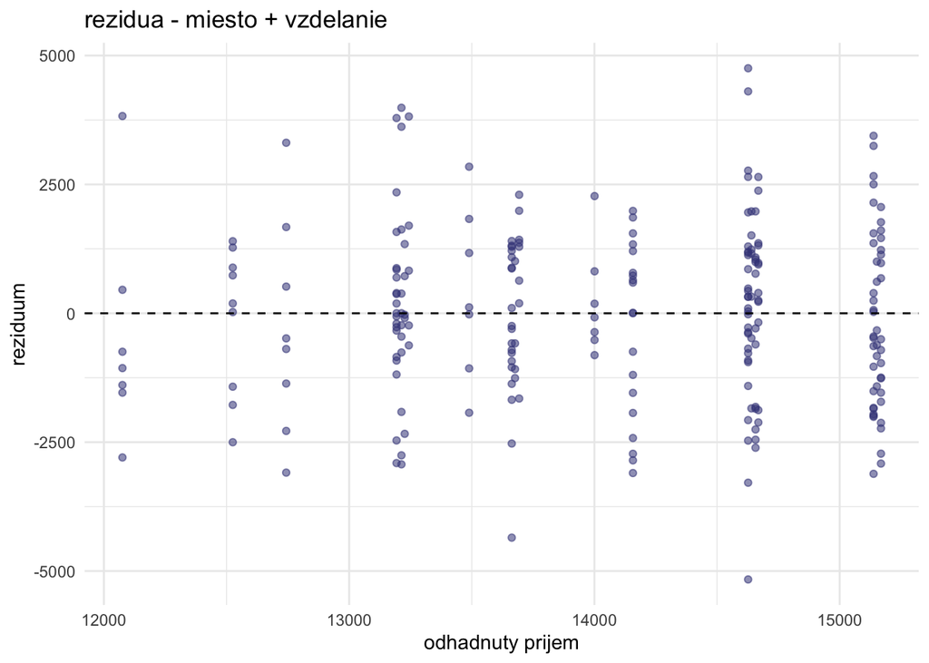

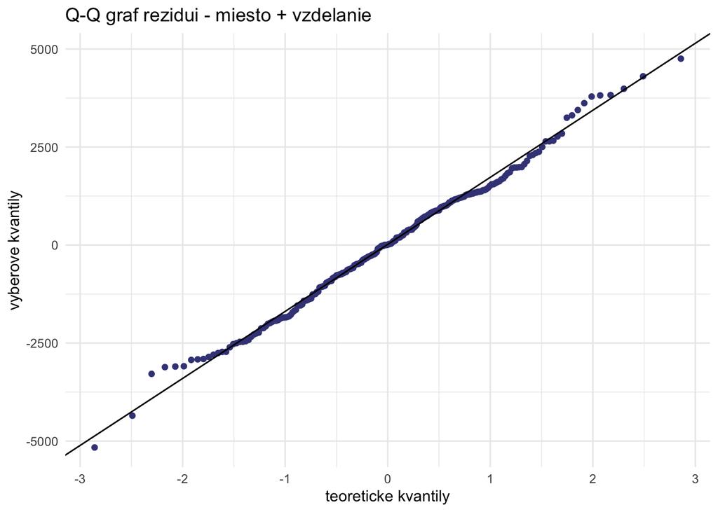

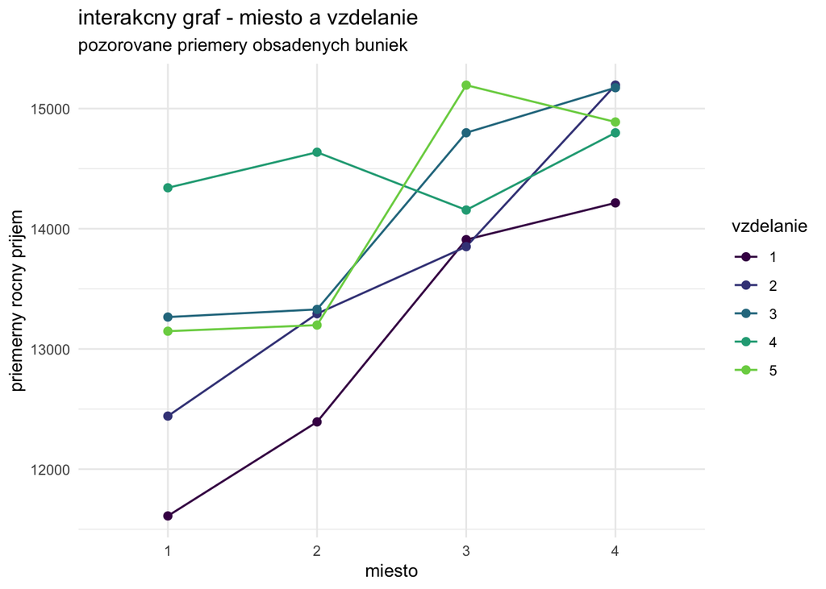

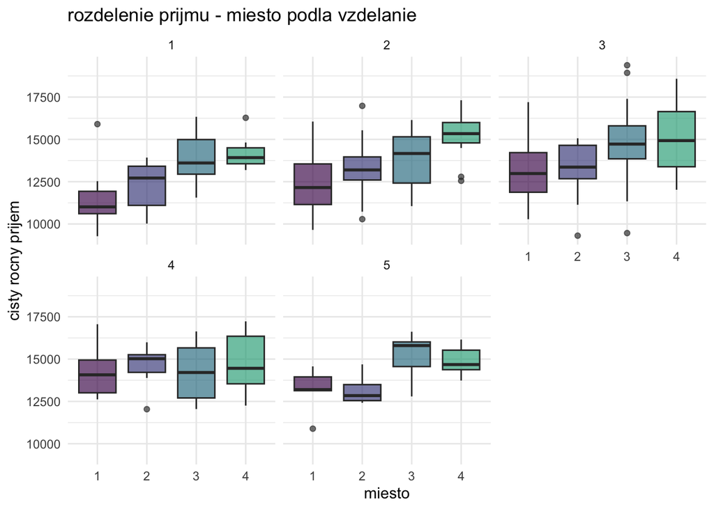

```
##
## upravene priemery a post hoc testy: miesto
##   skupina  priemer    dolna    horna
## 1       1 12900.39 12425.06 13375.72
## 2       2 13350.17 12966.39 13733.94
## 3       3 14313.95 13967.78 14660.11
## 4       4 14825.34 14462.67 15188.01
##   dvojica   rozdiel       se        t  df      dolna     horna            p
## 1     2-1  449.7790 364.4525 1.234122 227 -152.14860 1051.7066 2.184335e-01
## 2     3-1 1413.5602 350.6831 4.030876 227  834.37416 1992.7463 7.587140e-05
## 3     4-1 1924.9575 359.0325 5.361513 227 1331.98154 2517.9334 2.027024e-07
## 4     3-2  963.7812 300.6773 3.205368 227  467.18450 1460.3780 1.542936e-03
## 5     4-2 1475.1785 311.8755 4.730023 227  960.08676 1990.2702 3.944827e-06
## 6     4-3  511.3973 292.8516 1.746268 227   27.72533  995.0692 8.211720e-02
##         p_holm vyznamny
## 1 2.184335e-01    FALSE
## 2 3.034856e-04     TRUE
## 3 1.216215e-06     TRUE
## 4 4.628807e-03     TRUE
## 5 1.972414e-05     TRUE
## 6 1.642344e-01    FALSE
```

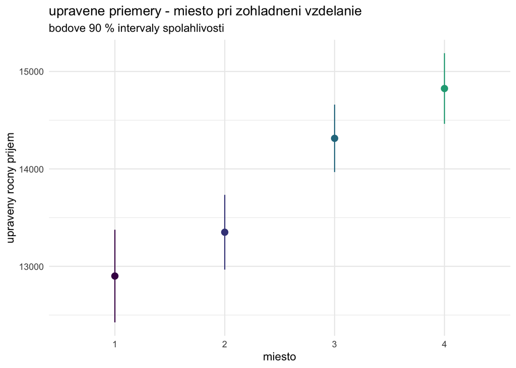

```
##
## upravene priemery a post hoc testy: vzdelanie
##   skupina  priemer    dolna    horna
## 1       1 13022.66 12505.28 13540.05
## 2       2 13690.45 13312.60 14068.29
## 3       3 14160.22 13838.83 14481.61
## 4       4 14190.42 13753.06 14627.79
## 5       5 14173.55 13568.80 14778.30
##    dvojica    rozdiel       se           t  df      dolna     horna           p
## 1      2-1  667.78166 387.0555  1.72528648 227   28.52312 1307.0402 0.085836815
## 2      3-1 1137.55740 368.7077  3.08525554 227  528.60205 1746.5128 0.002286305
## 3      4-1 1167.75826 410.5482  2.84438792 227  489.69940 1845.8171 0.004856107
## 4      5-1 1150.88473 482.3053  2.38621634 227  354.31227 1947.4572 0.017843607
## 5      3-2  469.77574 296.0139  1.58700563 227  -19.11903  958.6705 0.113903309
## 6      4-2  499.97660 347.9321  1.43699472 227  -74.66595 1074.6191 0.152096379
## 7      5-2  483.10307 431.5000  1.11958997 227 -229.55970 1195.7658 0.264071759
## 8      4-3   30.20086 323.6229  0.09332113 227 -504.29278  564.6945 0.925730755
## 9      5-3   13.32733 413.2340  0.03225128 227 -669.16747  695.8221 0.974300000
## 10     5-4  -16.87353 450.2137 -0.03747894 227 -760.44372  726.6967 0.970136072
##        p_holm vyznamny
## 1  0.60085770    FALSE
## 2  0.02286305     TRUE
## 3  0.04370496     TRUE
## 4  0.14274886    FALSE
## 5  0.68341985    FALSE
## 6  0.76048189    FALSE
## 7  1.00000000    FALSE
## 8  1.00000000    FALSE
## 9  1.00000000    FALSE
## 10 1.00000000    FALSE
```

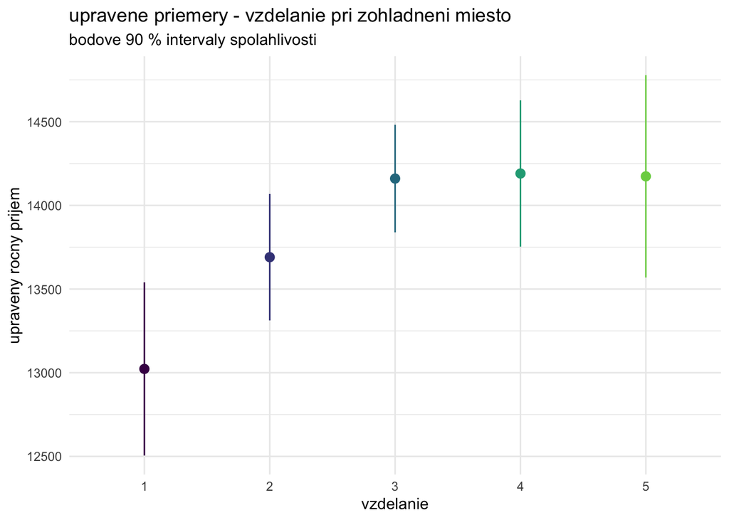

Pri $\alpha = 0,10$ sa interakcia nepreukazala ($p = 0,4700$), ale miesto ($p = 4,95 \times 10^{-8}$) aj vzdelanie ($p = 0,01806$) su vyznamne. Holmova korekcia potvrdila dvojice (3, 1), (4, 1), (3, 2), (4, 2) pre miesto a (3, 1), (4, 1) pre vzdelanie. Rovnost rozptylov ani normalitu rezidui nezamietame, normalitu jednej bunky vsak zamietame a vyznamnost oboch faktorov potvrdzuje aj HC3.

## vek a miesto

```r
vek_miesto <- dvojfaktorova("vek", "miesto")
```

```
##
##  vek + miesto
##    miesto
## vek  1  2  3  4
##   1  7 17 17 10
##   2 13 22 32 31
##   3  4  5  2  9
##   4  9 10 20 12
##   5  3  5  3  4
##      n  priemer   median        sd   rozptyl   minimum  maximum     dolna
## 1.1  7 12333.01 12453.60 1526.4945 2330185.4 10461.429 14839.07 11211.872
## 2.1 13 13471.52 13595.72 2420.4974 5858807.6 10283.204 17200.33 12275.027
## 3.1  4 13545.87 12896.41 2474.9927 6125588.7 11329.714 17060.94 10633.589
## 4.1  9 12798.43 13198.38 1916.9829 3674823.5  9652.543 15902.16 11610.194
## 5.1  3 11113.20 11299.56 1748.4879 3057209.8  9278.995 12761.04  8165.504
## 1.2 17 13440.71 13800.54 1305.6539 1704732.0 10024.071 14975.60 12887.843
## 2.2 22 12927.26 13015.52 1444.8165 2087494.7  9310.645 15119.53 12397.208
## 3.2  5 14316.13 14771.54 2395.5630 5738722.0 11101.604 16980.85 12032.222
## 4.2 10 13846.47 13947.03 1572.6838 2473334.5 10747.965 15682.46 12934.812
## 5.2  5 12861.35 12896.36 1265.1587 1600626.5 11136.574 14688.30 11655.161
## 1.3 17 14183.50 14350.39 1504.4975 2263512.8 11559.758 16584.71 13546.433
## 2.3 32 14546.26 14849.77 1348.0602 1817266.2 11058.067 16617.86 14142.212
## 3.3  2 13154.97 13154.97  443.1638  196394.2 12841.606 13468.33 11176.467
## 4.3 20 14742.89 14870.30 2524.1599 6371383.4 11303.748 19380.43 13766.937
## 5.3  3 12725.25 14053.02 2840.8961 8070690.6  9463.586 14659.15  7935.913
## 1.4 10 14778.49 14423.56 1512.5996 2287957.5 13129.921 17799.96 13901.663
## 2.4 31 14884.62 14688.94 1725.8767 2978650.4 12024.155 18581.67 14358.513
## 3.4  9 15270.58 15986.09 1574.8512 2480156.2 12551.216 17312.62 14294.406
## 4.4 12 15069.69 15223.50 1720.1631 2958961.2 12253.247 17640.42 14177.909
## 5.4  4 14672.20 14458.93  873.9987  763873.7 13922.181 15848.73 13643.777
##        horna p_shapiro skupina
## 1.1 13454.15 0.5602317     1.1
## 2.1 14668.02 0.3597581     2.1
## 3.1 16458.15 0.4166689     3.1
## 4.1 13986.68 0.7253196     4.1
## 5.1 14060.90 0.8234566     5.1
## 1.2 13993.57 0.1134647     1.2
## 2.2 13457.31 0.1165101     2.2
## 3.2 16600.04 0.8072420     3.2
## 4.2 14758.12 0.4609006     4.2
```

[output cut: 46 more lines]

```
## <none>              682549985 3513.2
## vek     4  20337944 702887929 3512.1   1.691     0.153
## miesto  3 131212685 813762671 3548.5  14.546 1.065e-08 ***
## ---
## Signif. codes:  0 '***' 0.001 '**' 0.01 '*' 0.05 '.' 0.1 ' ' 1
##   faktor parcialne_eta2
## 1    vek     0.02893483
## 2 miesto     0.16124196
##        R2
## 0.1896702
##
##  Shapiro-Wilk normality test
##
## data:  residuals(aditivny)
## W = 0.9934, p-value = 0.3852
```

```
## Coefficient covariances computed by hccm()
```

```
## Analysis of Deviance Table (Type II tests)
##
## Response: prijem
##            Df       F    Pr(>F)
## vek         4  1.5691    0.1834
## miesto      3 13.6608 3.182e-08 ***
## Residuals 227
## ---
## Signif. codes:  0 '***' 0.001 '**' 0.01 '*' 0.05 '.' 0.1 ' ' 1
```

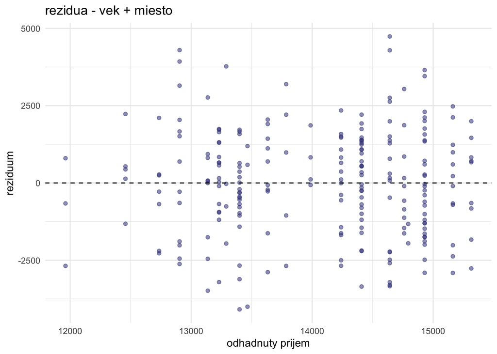

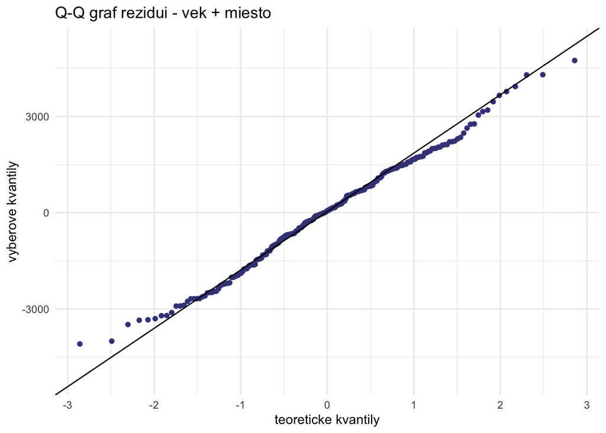

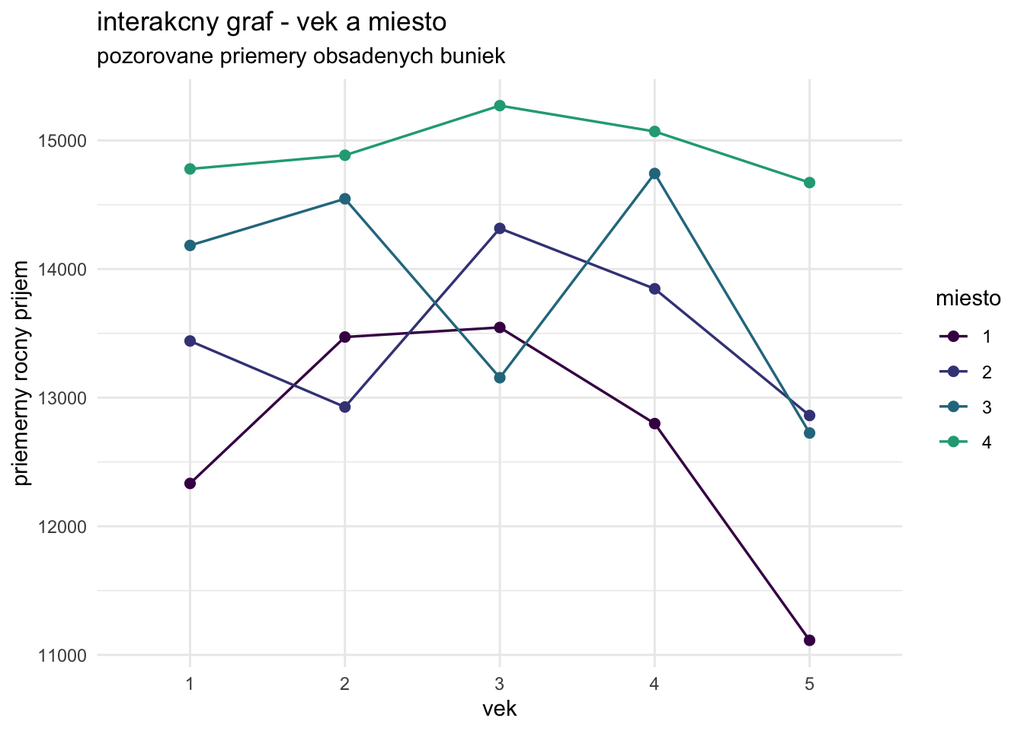

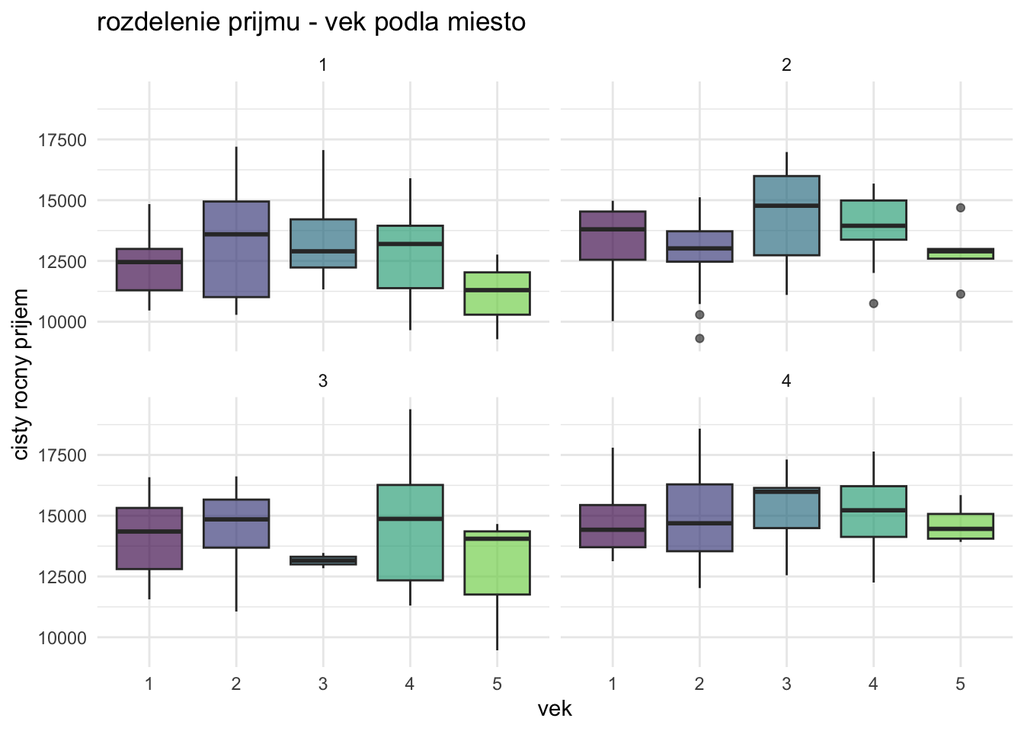

```
##
## upravene priemery a post hoc testy: miesto
##   skupina  priemer    dolna    horna
## 1       1 12805.28 12314.01 13296.54
## 2       2 13300.91 12906.05 13695.76
## 3       3 14309.63 13931.26 14687.99
## 4       4 14831.08 14452.53 15209.63
##   dvojica   rozdiel       se        t  df      dolna    horna            p
## 1     2-1  495.6329 368.1137 1.346413 227 -112.34143 1103.607 1.795124e-01
## 2     3-1 1504.3502 354.8014 4.239978 227  918.36235 2090.338 3.254271e-05
## 3     4-1 2025.8022 360.6106 5.617700 227 1430.21999 2621.384 5.635765e-08
## 4     3-2 1008.7173 305.6769 3.299946 227  503.86317 1513.571 1.122834e-03
## 5     4-2 1530.1694 313.8139 4.876040 227 1011.87619 2048.463 2.034754e-06
## 6     4-3  521.4521 298.3716 1.747660 227   28.66344 1014.241 8.187504e-02
##         p_holm vyznamny
## 1 1.795124e-01    FALSE
## 2 1.301708e-04     TRUE
## 3 3.381459e-07     TRUE
## 4 3.368501e-03     TRUE
## 5 1.017377e-05     TRUE
## 6 1.637501e-01    FALSE
```

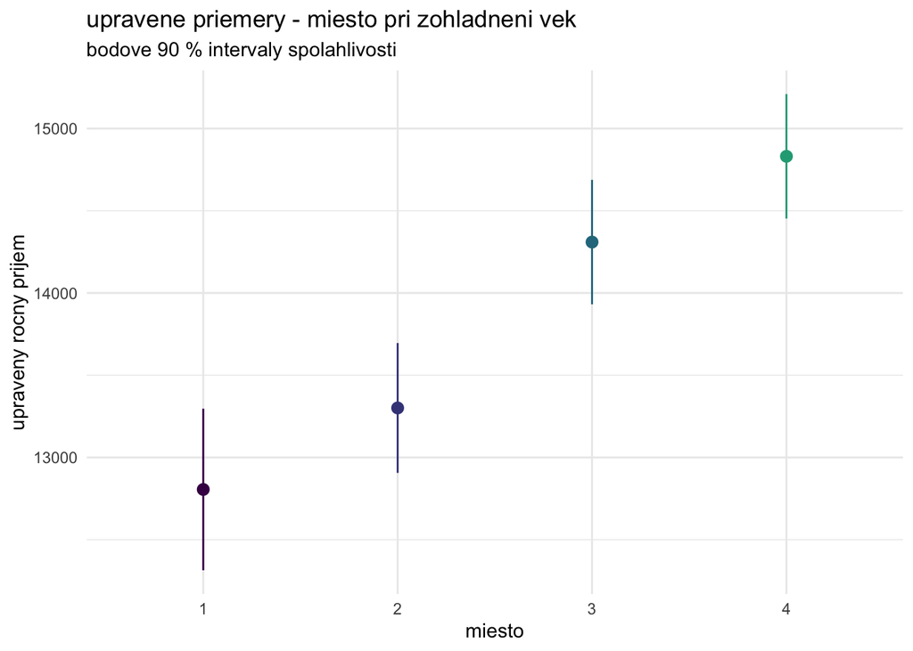

Interakcia sa nepreukazala ($p = 0,7115$), vyznamne je iba miesto ($p = 1,06 \times 10^{-8}$), nie vek ($p = 0,1530$). Holmova korekcia potvrdila dvojice miest (3, 1), (4, 1), (3, 2), (4, 2) a HC3 potvrdzuje rozhodnutie o faktoroch. Nerovnake rozptyly a bunka s iba dvoma osobami obmedzuju spolahlivost analyzy, klasicke post hoc vysledky preto berieme ako orientacne.

## vek a sektor

```r
vek_sektor <- dvojfaktorova("vek", "sektor")
```

```
##
##  vek + sektor
##    sektor
## vek  1  2  3
##   1 20 14 17
##   2 31 35 32
##   3  7  4  9
##   4 19 18 14
##   5  6  4  5
##      n  priemer   median        sd   rozptyl   minimum  maximum    dolna
## 1.1 20 13927.08 13879.51 1567.8477 2458146.4 10461.429 17799.96 13320.88
## 2.1 31 14209.12 14322.46 1815.0236 3294310.5 10283.204 17200.33 13655.83
## 3.1  7 14173.49 13468.33 2096.8099 4396611.7 11329.714 16980.85 12633.48
## 4.1 19 14086.30 13416.96 2208.6704 4878224.9 10747.965 18931.50 13207.65
## 5.1  6 12457.07 12792.76 1983.6312 3934792.6  9278.995 14688.30 10825.25
## 1.2 14 13769.18 14203.87 1843.5595 3398711.6 10024.071 16584.71 12896.62
## 2.2 35 14012.20 13585.41 2016.1317 4064787.1  9310.645 18581.67 13435.95
## 3.2  4 14667.99 14413.85 2354.5007 5543673.8 12531.657 17312.62 11897.49
## 4.2 18 14630.97 14775.06 2351.5363 5529723.1 10683.755 19380.43 13666.77
## 5.2  4 14039.40 14290.66  937.0086  877985.1 12761.041 14815.24 12936.84
## 1.3 17 13671.61 13887.26 1497.7829 2243353.5 10536.471 16628.35 13037.39
## 2.3 32 14235.11 14449.45 1630.6746 2659099.6 10457.755 16689.81 13746.35
## 3.3  9 14624.77 14771.54 1940.7525 3766520.1 11101.604 17060.94 13421.79
## 4.3 14 14167.68 14246.53 2033.3186 4134384.4  9652.543 17272.87 13205.31
## 5.3  5 12722.17 12896.36 2467.4665 6088391.1  9463.586 15848.73 10369.71
##        horna p_shapiro skupina
## 1.1 14533.28 0.8035196     1.1
## 2.1 14762.41 0.3690539     2.1
## 3.1 15713.49 0.5220245     3.1
## 4.1 14964.96 0.5954806     4.1
## 5.1 14088.88 0.7708723     5.1
## 1.2 14641.74 0.7590980     1.2
## 2.2 14588.45 0.2851953     2.2
## 3.2 17438.49 0.3067673     3.2
## 4.2 15595.16 0.9144772     4.2
## 5.2 15141.96 0.4009843     5.2
## 1.3 14305.83 0.9911931     1.3
## 2.3 14723.87 0.1456755     2.3
## 3.3 15827.74 0.5730390     3.3
## 4.3 15130.06 0.8588607     4.3
```

[output cut: 32 more lines]

```
## <none>              813007873 3552.3
## vek     4  28170477 841178349 3552.3  1.9750 0.09918 .
## sektor  2    754798 813762671 3548.5  0.1058 0.89961
## ---
## Signif. codes:  0 '***' 0.001 '**' 0.01 '*' 0.05 '.' 0.1 ' ' 1
##   faktor parcialne_eta2
## 1    vek   0.0334893031
## 2 sektor   0.0009275407
##         R2
## 0.03478938
##
##  Shapiro-Wilk normality test
##
## data:  residuals(aditivny)
## W = 0.99423, p-value = 0.5089
```

```
## Coefficient covariances computed by hccm()
```

```
## Analysis of Deviance Table (Type II tests)
##
## Response: prijem
##            Df      F Pr(>F)
## vek         4 1.8029 0.1291
## sektor      2 0.0949 0.9095
## Residuals 228
```

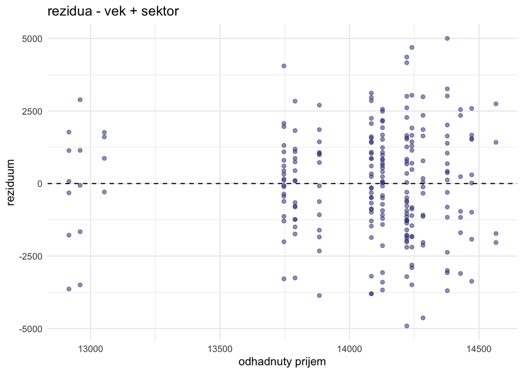

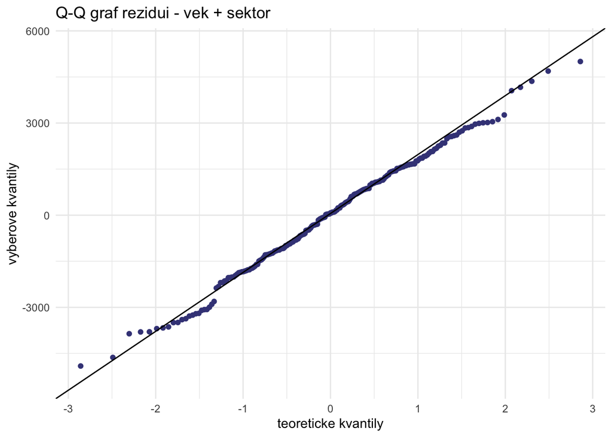

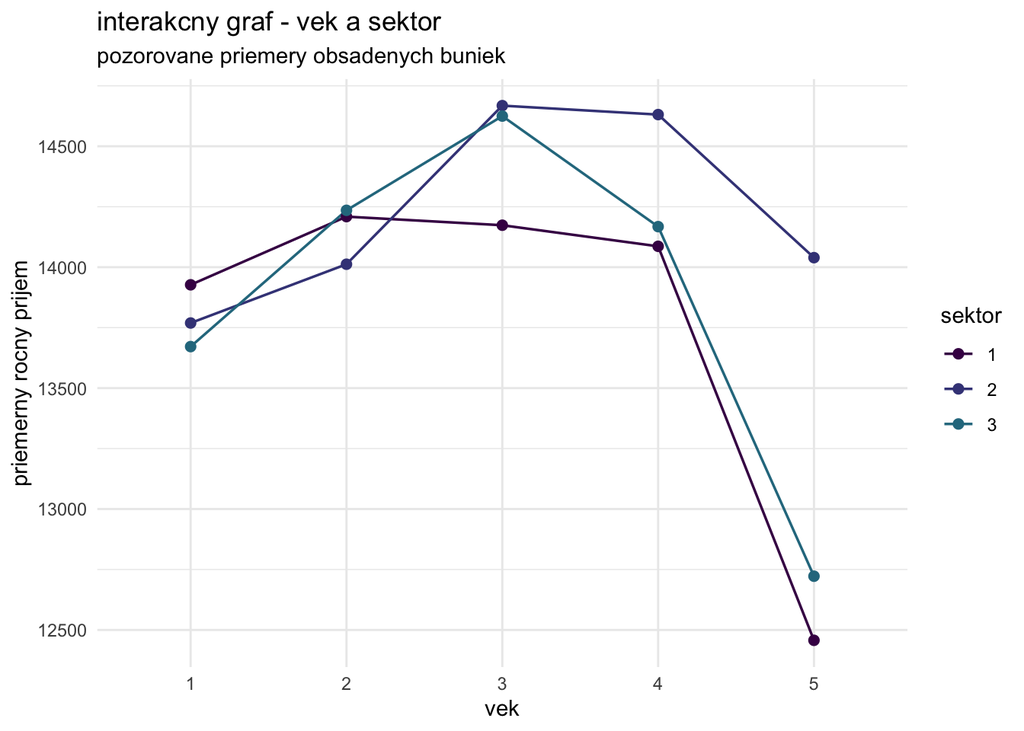

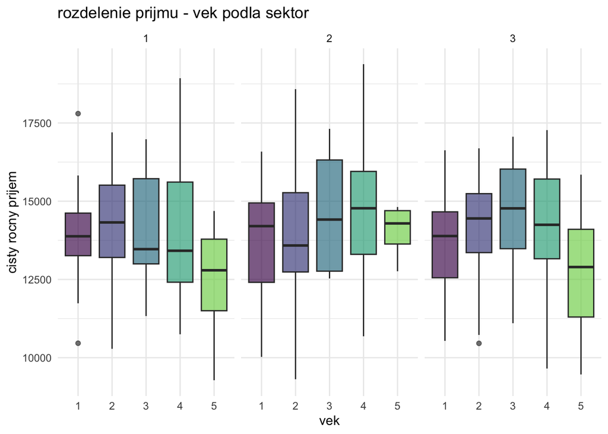

```
##
## upravene priemery a post hoc testy: vek
##   skupina  priemer    dolna    horna
## 1       1 13806.63 13368.93 14244.32
## 2       2 14144.31 13829.09 14459.53
## 3       3 14488.68 13788.37 15188.99
## 4       4 14300.73 13863.25 14738.21
## 5       5 12976.52 12170.58 13782.45
##    dvojica    rozdiel       se          t  df      dolna      horna          p
## 1      2-1   337.6861 326.9301  1.0328999 228  -202.2600  877.63225 0.30274512
## 2      3-1   682.0527 499.1893  1.3663209 228  -142.3904 1506.49587 0.17318427
## 3      4-1   494.1024 374.5819  1.3190771 228  -124.5437 1112.74851 0.18846656
## 4      5-1  -830.1106 554.6579 -1.4966175 228 -1746.1637   85.94244 0.13587581
## 5      3-2   344.3666 465.4365  0.7398789 228  -424.3316 1113.06488 0.46013465
## 6      4-2   156.4163 326.4465  0.4791485 228  -382.7310  695.56361 0.63229225
## 7      5-2 -1167.7967 524.2196 -2.2276862 228 -2033.5791 -302.01441 0.02687825
## 8      4-3  -187.9503 500.7995 -0.3753005 228 -1015.0529  639.15229 0.70778592
## 9      5-3 -1512.1634 645.7329 -2.3417783 228 -2578.6327 -445.69397 0.02005424
## 10     5-4 -1324.2131 555.1517 -2.3853177 228 -2241.0817 -407.34443 0.01788253
##       p_holm vyznamny
## 1  1.0000000    FALSE
## 2  1.0000000    FALSE
## 3  1.0000000    FALSE
## 4  0.9511307    FALSE
## 5  1.0000000    FALSE
## 6  1.0000000    FALSE
## 7  0.2150260    FALSE
## 8  1.0000000    FALSE
## 9  0.1804881    FALSE
## 10 0.1788253    FALSE
```

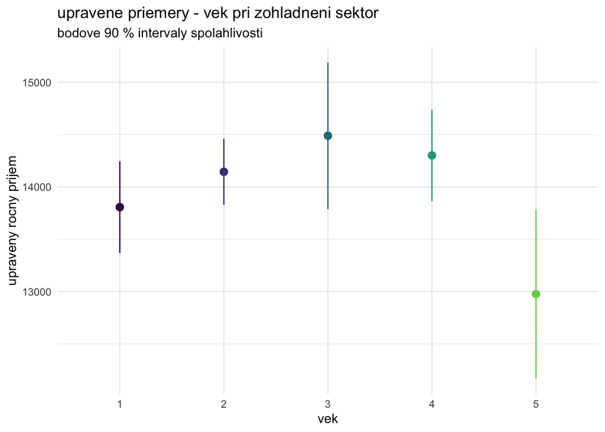

Normalitu ani rovnost rozptylov pri $\alpha = 0,10$ nezamietame, interakcia ($p = 0,9247$) ani sektor ($p = 0,89961$) nie su vyznamne. Vek je tesne vyznamny ($p = 0,09918$), ale celkovy model ($p = 0,22777$) ani ziadna vekova dvojica po Holmovej korekcii vyznamne nie su. HC3 vyznamnost veku nepotvrdzuje ($p = 0,1291$), preto je tento vysledok citlivy na pouzitu metodu.